# MONTGOMERY COUNTY JAIL

# Informe estadístico del centro de detención de ICE

*Datos al 9 de julio de 2026 - Con cálculos de PDP por intervalo*

[*Volver a Detention Reports*](https://detentionreports.com/es/)

Read in English

## Estadísticas clave

| Indicador del centro | Valor |
| --- | --- |
| Dirección | Park Street, Fonda, NY 12068 |
| Población diaria promedio total (PDP por intervalo) | 3 |
| Duración promedio de la estancia | 2 días |
| Población masculina | 3 |
| Población femenina | 0 |
| Población con condena penal | 0 |
| Población sin condena penal | 2 |
| Tipo de centro | USMS IGA |
| Área de responsabilidad (AOR) | BUF |
| Mínimo garantizado | No disponible |
| Propietario | Montgomery County |
| Operador | Montgomery County Sheriff's Office |
| Tipo de institución | Local |

## Ubicación del centro de detención

Mapa que muestra la ubicación de Montgomery County Jail en Park Street, Fonda, NY 12068.

[interactive chart not shown]

[🗺️ View Interactive Map](https://maps.google.com/maps?q=42.952646,-74.375827) [🧭 Get Directions](https://www.google.com/maps/dir//42.952646,-74.375827)

## Población diaria promedio por intervalo (PDP por intervalo)

Es un cálculo de promedio móvil retrospectivo de la población de cada centro, basado en datos de ICE. Para más información, consulte el documento de referencia [aquí](https://relevant-research.com/work) (en inglés).

[figure not shown]

## Gráfico de dispersión: duración promedio de la estancia y PDP por intervalo

[figure not shown]

## PDP por intervalo según clasificación de los detenidos

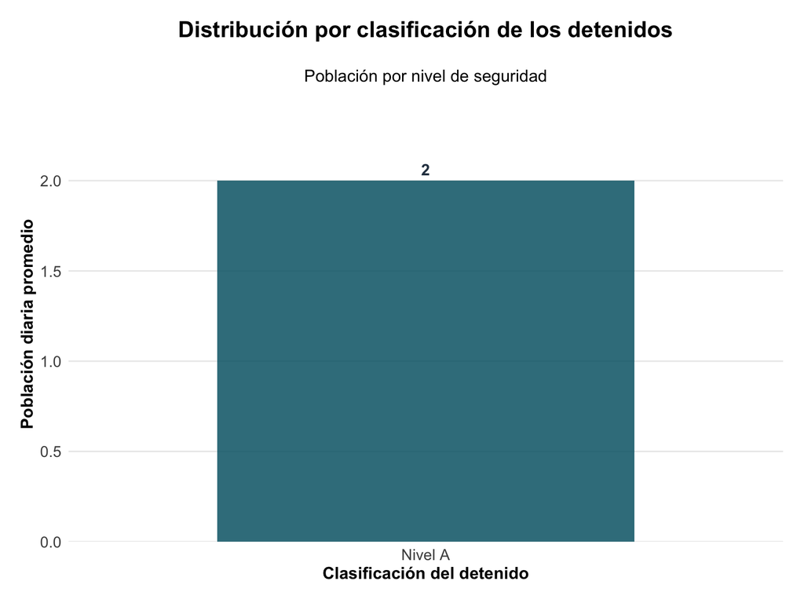

ICE define estas clasificaciones de la siguiente manera:

*Al ingresar, y periódicamente después, los detenidos se clasifican en un nivel de seguridad según diversos factores de seguridad pública, y se les aloja en consecuencia.*

*Los factores incluyen condenas previas, riesgo de amenaza, historial disciplinario, vulnerabilidades especiales y consideraciones especiales de manejo.*

*Los detenidos se clasifican en una de cuatro categorías de riesgo de seguridad:*

- *A/bajo*
- *B/medio bajo*
- *C/medio alto*
- *D/alto*

*Debido al redondeo, la suma de los totales por clasificación de seguridad puede no coincidir con la PDP por intervalo total del centro. Consulte la página de [notas](https://detentionreports.com/facility/es/notes.html) para más información.

## PDP por intervalo según género y condición penal

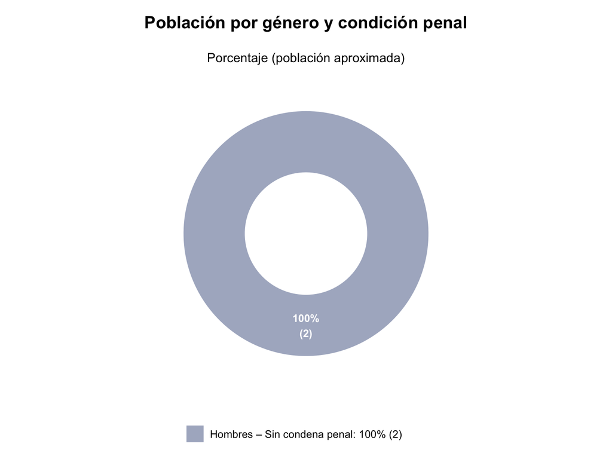

ICE define la condición penal de la siguiente manera:

- *Con condena penal (Convicted Criminal):*
  - *Infractores de las leyes de inmigración con una condena penal registrada en los sistemas de ICE al momento de quedar bajo custodia de ICE.*
- *Con cargos penales pendientes (Pending Criminal Charges):*
  - *Infractores de las leyes de inmigración con cargos penales pendientes registrados en los sistemas de ICE al momento de quedar bajo custodia de ICE.*
- *Otros infractores de las leyes de inmigración (Other Immigration Violators):*
  - *Infractores de las leyes de inmigración sin condena penal conocida ni cargos pendientes registrados en los sistemas de ICE al momento de quedar bajo custodia de ICE.*

En sus informes por centro, ICE reduce estas tres categorías a dos: “Criminal” (con condena penal) y “Non-Criminal” (sin condena penal). La documentación de las estadísticas de detención de ICE no explica claramente su método para desagregar la condición penal. Al comparar porcentajes con otros indicadores que publica ICE, todo indica que ICE incluye a las personas con cargos penales pendientes dentro de la categoría “Non-Criminal” en sus informes.

*Debido al redondeo, la suma de los totales por género y condición penal puede no coincidir con la PDP por intervalo total del centro. Consulte la página de [notas](https://detentionreports.com/facility/es/notes.html) para más información.

## Detención obligatoria

Algunas secciones de la Ley de Inmigración y Nacionalidad (INA) exigen la detención de ciertas personas bajo lo que se conoce como “detención obligatoria”. Por lo general, las personas en detención obligatoria no pueden salir bajo fianza. ICE reporta la población en detención obligatoria de cada centro como una población diaria promedio del año fiscal. Consulte las [notas](https://detentionreports.com/facility/es/notes.html) para más detalles.

[figure not shown]

## Información sobre contratos

*No se encontraron contratos para este centro.*

[*Volver a Detention Reports*](https://detentionreports.com/es/)

*Informe generado el 1 de octubre de 2026 con datos de PDP por intervalo del sistema Integrated Decision Support (IIDS) de ICE del 9 de julio de 2026*

Desarrollado por [Relevant Research](https://relevant-research.com/). Para información sobre la metodología de la PDP por intervalo, [haga clic aquí](https://relevant-research.com/work) (en inglés).